# World Bank Tobacco Analysis

Robin Billinger, Leonie Mertes

2025-01-20

## Introduction

This analysis explores relationships between indicators across countries such as GDP per capita and prevalence of current tobacco usage (% of adults) using World Bank data. The question to be investigated is:  
1. How does **GDP per capita** relate to the **prevalence of current tobacco use (% of adults)**?  
The upon mentioned indicators taken into consideration during this analysis are defined in the following table.

World Bank Indicators

| Variable | Indicator Name | Definition |
| --- | --- | --- |
| NY.GDP.PCAP.PP.KD | GDP per capita, PPP (constant 2021 international $) | GDP per capita based on purchasing power parity (PPP). PPP GDP is gross domestic product converted to international dollars using purchasing power parity rates. An international dollar has the same pu… |
| SH.PRV.SMOK | Prevalence of current tobacco use (% of adults) | The percentage of the population ages 15 years and over who currently use any tobacco product (smoked and/or smokeless tobacco) on a daily or non-daily basis. Tobacco products include cigarettes, pipe… |

(*Sources: https://data.worldbank.org/indicator/NY.GDP.PCAP.PP.KD?view=chart, https://data.worldbank.org/indicator/SH.PRV.SMOK?view=chart*)

## Grouping of the countries

The countries are grouped by their Prevalence of current tobacco use based on the quantiles of the average values of the tobacco variable. In the following, they are categorized into five categories.  
Since it is not always helpful to group over the average, an annual grouping is also used in the course of the script. Here, each country was categorized by quantiles over the tobacco variable each year.

## Terminology and Methodological Approach

To mitigate issues with data quality and variance in data, we employ robust statistical techniques, including:

- **Robust Linear Models (RLMs)** for trend estimation, which are less sensitive to **outliers**.
- **Confidence Intervals** to provide insight into the **uncertainty of our estimates**.

#### Robust Linear Models

Traditional **Ordinary Least Squares (OLS)** estimates regression coefficients by minimizing the sum of squared residuals:

$$\min_{\beta} \sum_{i=1}^{n} (y_i - X_i \beta)^2$$

This approach provides **BLUE (Best Linear Unbiased Estimators)** under the **Gauss-Markov theorem**, but relies on the assumption that residuals are **normally distributed**. Given the inconsistencies in our dataset, this assumption is likely invalid. While OLS estimates remain **unbiased** but may become less efficient, potentially affecting the reliability of **confidence intervals and hypothesis tests**.

To address this, we use **Robust Linear Models (RLMs)**, specifically M-estimators, as implemented in `MASS::rlm()`. These models apply **Iteratively Reweighted Least Squares (IRLS)**, assigning smaller weights to outliers. Instead of minimizing squared residuals, RLMs use **alternative loss functions** that reduce the impact of extreme values.

In our analysis, we use the default psi function, **psi.huber**, which is based on **Huber’s loss function**:

$$L_{\delta}(r) =
\begin{cases}
\frac{1}{2} r^2 & \text{for } |r| \leq \delta, \\
\delta (|r| - \frac{1}{2} \delta) & \text{for } |r| > \delta.
\end{cases}$$

where:

- $r$ is the **residual** $y_i - X_i \beta$
- $\delta$ is the **threshold parameter** (default in R: **1.345**)

This method ensures **small residuals** behave like **OLS**, while **large residuals** have **reduced influence**, making RLMs more resistant to **outliers and non-normal residual distributions**.

#### Confidence Intervals

By default, `geom_smooth(method = MASS::rlm)` displays confidence intervals. However, unlike **ordinary least squares (OLS)**, `MASS::rlm()` does **not automatically provide standard errors**, as robust regression does not make the same assumptions about variability in the data.

The confidence intervals shown in `geom_smooth()` are based on an **approximation** rather than **true robust standard errors**. Specifically, `ggplot2` estimates confidence intervals using the **standard formula for least squares regression**:

$$CI = \hat{y} \pm t_{\alpha/2, df} \cdot SE(\hat{y})$$

where:

- $\hat{y}$ is the **predicted value** from the robust regression model
- $SE(\hat{y})$ is the **standard error of the fitted values**, approximated using **local smoothing techniques**
- $t_{\alpha/2, df}$ is the **critical t-value** for a 95% confidence level

Since robust regression methods like `rlm()` do not inherently calculate standard errors, the confidence intervals shown by `geom_smooth()` are **only an approximation**. A more rigorous approach would involve computing **robust standard errors manually** using the **Huber-White sandwich estimator** or **bootstrapping techniques**.

For simplicity, we retain the default confidence bands provided by `geom_smooth()`, while acknowledging that they do not fully account for the robustness adjustments of `rlm()`.

## Agenda

1.) GDP per capita and prevalence of current tobacco usage  
1.1.) Exploration of data with general grouping and application of yearly grouping  
1.2.) Scatter plot of interested variables  
1.3.) Scatter plot of interested variables; except outlier Qatar  
1.4.) Scatter plot of interested variables with faceted years  
1.5.) Scatter plot of interested variables with faceted years with density curves  
1.6.) Kullback-Leibler divergence for tobacco usage

### 1. GDP per capita and prevalence of current tobacco use

We analyze how the GDP per capita for the observed countries relates to the prevalence of current tobacco use, representing the percentage of adults currently consuming tobacco. To get an overview over the interested data and be able to evaluate future insights correctly, we start by looking at the data available to us.

```
## [1] "Are there no missing values? - Answer: FALSE"
```

```
## [1] "How many missing values are in the data regarding GDP per capita? - Answer: 0"
```

```
## [1] "How many missing values are in the data regarding tobacco prevalence? - Answer: 382"
```

```
## # A tibble: 1 × 3
## # Groups:   Country Name [1]
##   `Country Name` SH.PRV.SMOK     n
##   <chr>                <dbl> <int>
## 1 Aruba                   NA    22
```

As we can see, there is no data available for Aruba during the 22 years of time stretching from 2000 to 2021. Therefore, we drop Aruba from our analysis. Further, we check if there are any years in which the data is missing for several countries at the same time.

```
## # A tibble: 7 × 2
##    Year count_na
##   <int>    <int>
## 1  2000        1
## 2  2005        1
## 3  2010        1
## 4  2015        1
## 5  2018        1
## 6  2019        1
## 7  2020        1
```

Knowing there are only 25 countries to investigate, we only have data of the years 2000, 2005, 2010, 1015, 1018, 2019 and 2020 on percentage of tobacco usage in the adult population of all 24 countries (excluding Aruba). We adjust our data accordingly, so that those years will be the only ones we are considering when moving forward.

#### 1.1. Exploration of data with general grouping and derivation/application of yearly grouping

For an overview we take a look at the comparison of tobacco usage and GDP in 2020, our most recent data. We add an linear regression line to get a better impression on the overall coherence.

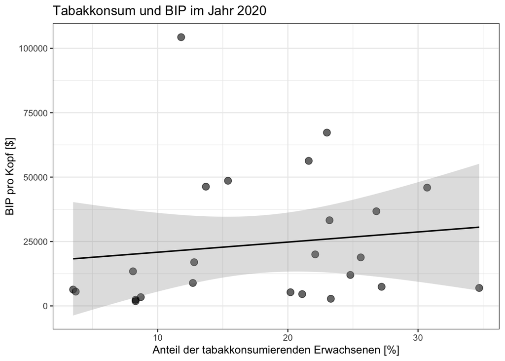

If we take the general categorization of the countries by the tobacco variable into account and plot only one point per group by calculating their mean, the following plot is created.

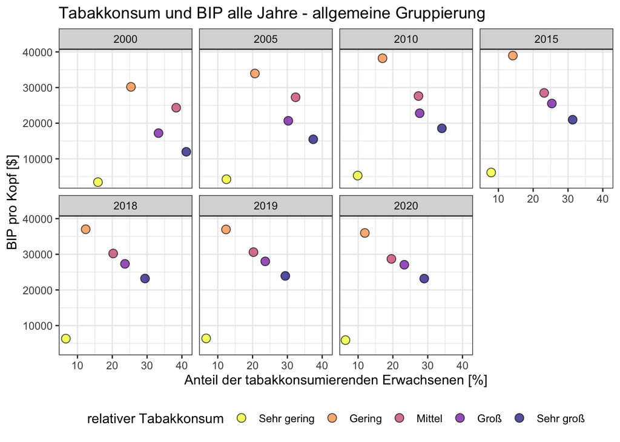

Here we see that the grouping is not appropriate for each year. For example, in the years 2000 and 2005 we see that countries with relative medium tobacco use have on average a larger proportion of tobacco users than countries belonging to the group of relative high tobacco use. So there appear to be countries that have such fluctuating tobacco use rates over the years that they belong to different groups depending on the year.  
This can be seen particularly well in the plot below. Here, the outlier belongs to different groups over the years. We look at the annual grouping of countries according to the quantils of their tobacco variables of the corresponding year.  
In the following plot, all data points are visible. This also shows that the annual grouping creates correct classifications.

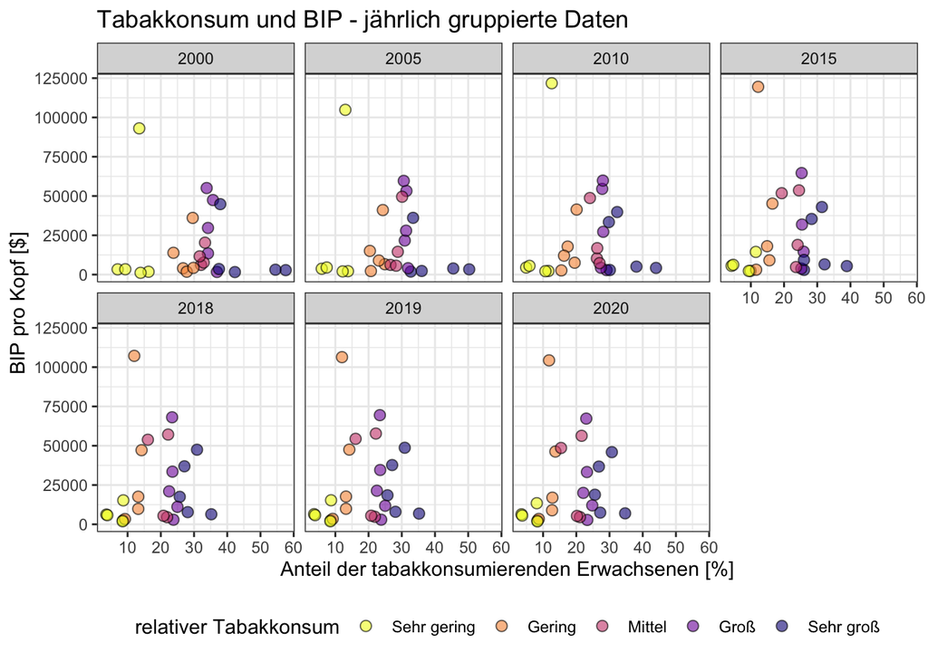

Now, if we apply the new grouping to a bar plot showing the average values of all years for each group, the distribution is as follows:

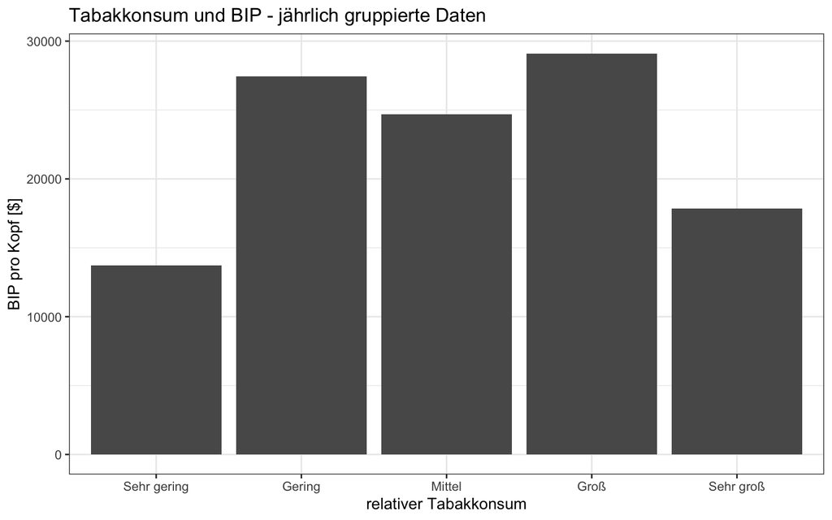

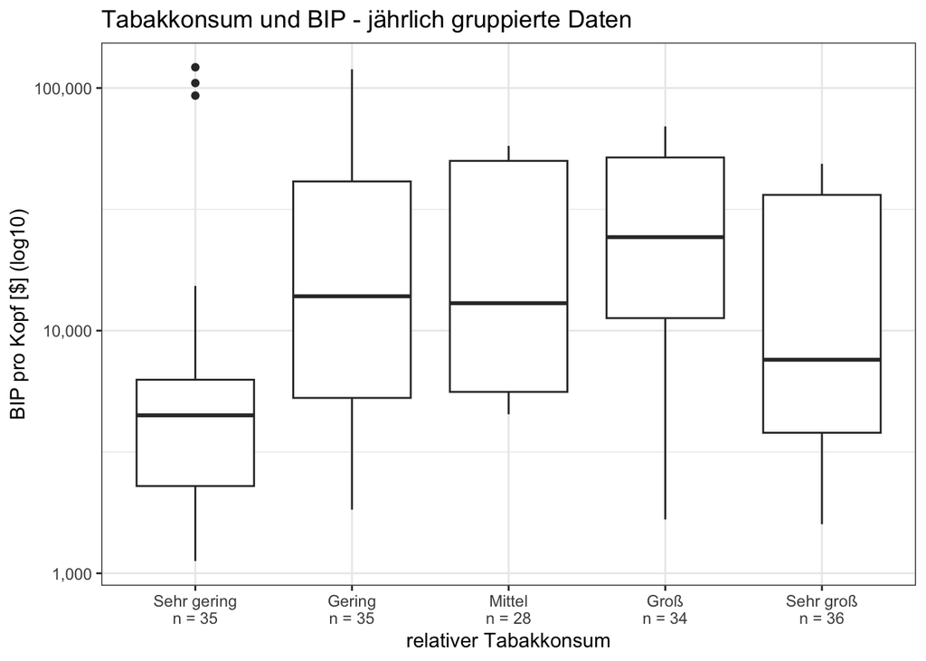

This shows that the average calculations are representative of the data because they are similar to the distribution by the medians.  
The following bar plots visualize the relationship between GDP and tobacco use quite well.

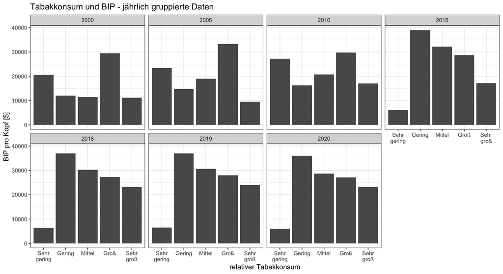

For the years 2000, 2005 and 2010, countries with very low and high average tobacco use had a higher GDP per capita in the dataset.  
This changes in 2015, 2018, 2019 and 2020. It is striking that countries with relatively very low tobacco use now had the lowest GDP per capita of all the countries listed.  
For all other categories of relative tobacco use it seems, that countries with relatively high tobacco use show a lower GDP per capita.

In the following, we want to investigate the relationship further by taking a step back and looking at the data without the yearly grouping. This is now done by starting with the initial comparison of the two variables without taking the time of data acquisition into account.

#### 1.2. Scatter plot of interested variables

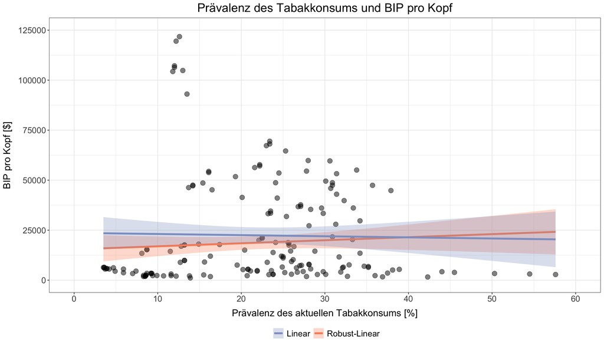

We observe a slight positive relationship while the direction of this relationship seems to be heavily influenced by the high GDP per capita and low tobacco prevalence outliers in the upper left hand area of the plot according to the different regression models used.  
As we are looking at the data without any consideration of time, we want to check whether those data points all belong to the same country and, if that is actually the case, what the relationship would look like without this one-country-bias.

#### 1.3. Scatter plot of interested variables; except outlier Qatar

```
## # A tibble: 7 × 6
##   `Country Name` `Country Code`  Year NY.GDP.PCAP.PP.KD SH.PRV.SMOK
##   <chr>          <chr>          <int>             <dbl>       <dbl>
## 1 Katar          QAT             2000            93050.        13.5
## 2 Katar          QAT             2005           104825.        13
## 3 Katar          QAT             2010           121765.        12.6
## 4 Katar          QAT             2015           119502.        12.2
## 5 Katar          QAT             2018           107185.        12
## 6 Katar          QAT             2019           106366.        12
## 7 Katar          QAT             2020           104322.        11.8
## # ℹ 1 more variable: cat_tob_usage <ord>
```

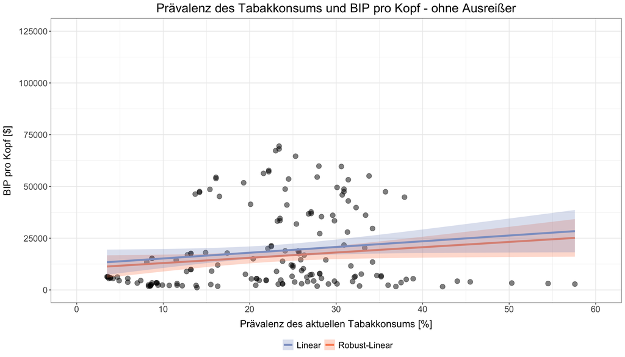

The removal of the Qatari data points leads us to slightly positive relationships for both, the linear as well as the robust-linear regression, visualized by the basically parallel straights divided only by marginal vertical differences.  
Keeping this influence of the outliers in mind, we want to do the small intermediate step to check which of the linear relationship is actually represented in each of the observable years and introduce another form of regression to get deeper understanding of how much the robust-linear representation is appropriate.

#### 1.4. Scatter plot of interested variables with faceted years

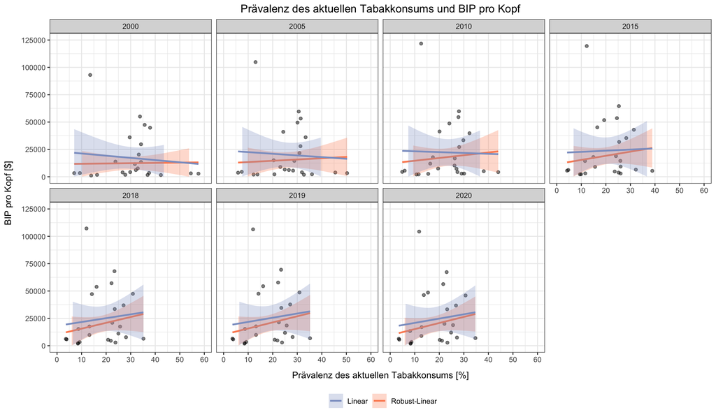

It seems that the Qatari data point in each of the years is still highly influential on the linear relationship. However, the relationship develops to more synchronized behaviour between the robust and non-robust relationship, with the non-robust changing from slightly negative to slightly positive.  
But looking at the distribution of the data points within each facet, something very interesting is happening. With the higher density of points in the horizontal middle of the cloud and the simultaneous deviation of some of those points in the higher GDP direction, we can recognize a presumably new relationship we want to visualize next.

#### 1.5. Scatter plot of interested variables with faceted years with density curves

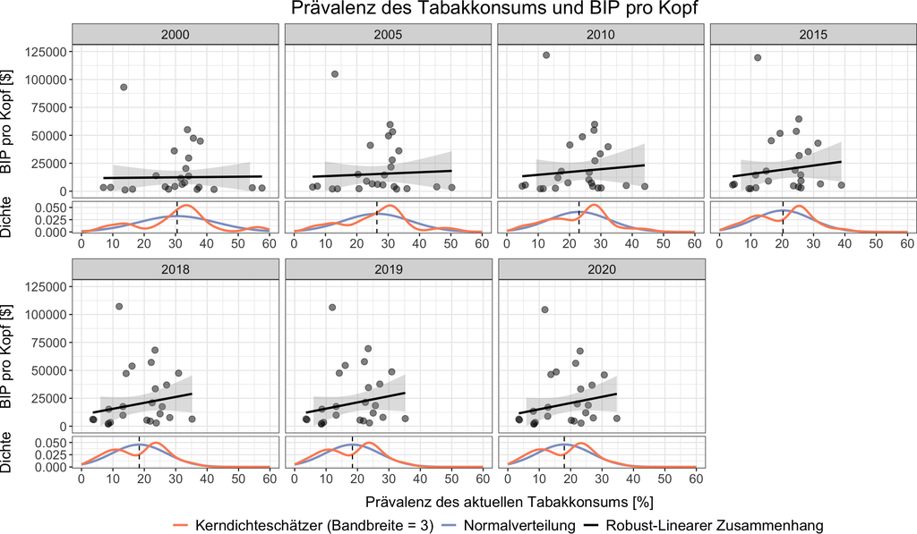

#### 1.6. Kullback-Leibler divergence for tobacco usage

This can be proven by calculating the Kullback-Leibler divergence for each of the years, comparing the KDE with the underlying normal distribution to check the accuracy of describing our empirical distribution by normal distribution.

| Jahr | KLD (Breite = 2) | KLD (Breite = 3) | KLD (Breite = 4) | KLD (Breite = 5) |
| --- | --- | --- | --- | --- |
| 2000 | 2.200456 | 1.3355127 | 0.7760908 | 0.4404161 |
| 2005 | 1.586584 | 0.8072496 | 0.4215260 | 0.2421420 |
| 2010 | 1.240258 | 0.5280582 | 0.2541619 | 0.1773269 |
| 2015 | 1.320069 | 0.5467187 | 0.2812418 | 0.2232322 |
| 2018 | 1.242548 | 0.5700443 | 0.3211268 | 0.2709994 |
| 2019 | 1.242548 | 0.5700443 | 0.3211268 | 0.2709994 |
| 2020 | 1.229573 | 0.5707539 | 0.3241600 | 0.2755441 |